## Load the dataset

```r
df_csv <- read.csv("../data/raw_data.csv")
```

We remove the rows with missing values in the ‘Entry’ column, then convert the categorical ‘Treatment’ column to a factor with four levels (for each of the four brightness conditions).

```r
df <- subset(df_csv,!(is.na(Entry)))
df$Treatment <- factor(df$Treatment, levels=unique(df$Treatment))
```

We then make subsets of the complete dataset for each of the four brightness conditions / Treatments:

```r
right_bright_df <- subset(df, Treatment=="Dark-Bright")
left_bright_df <- subset(df, Treatment=="Bright-Dark")
bright_df <- subset(df, Treatment=="Bright-Bright")
dark_df <- subset(df, Treatment=="Dark-Dark")
```

## Histograms

We plot the distribution of the horizontal position of the birds as they first enter the tunnel for the whole dataset, then for each of the four brightness conditions individually.  
On the x-axis, -1 represents the left edge, 0 the middle, and 1 the right edge of the tunnel entrance.

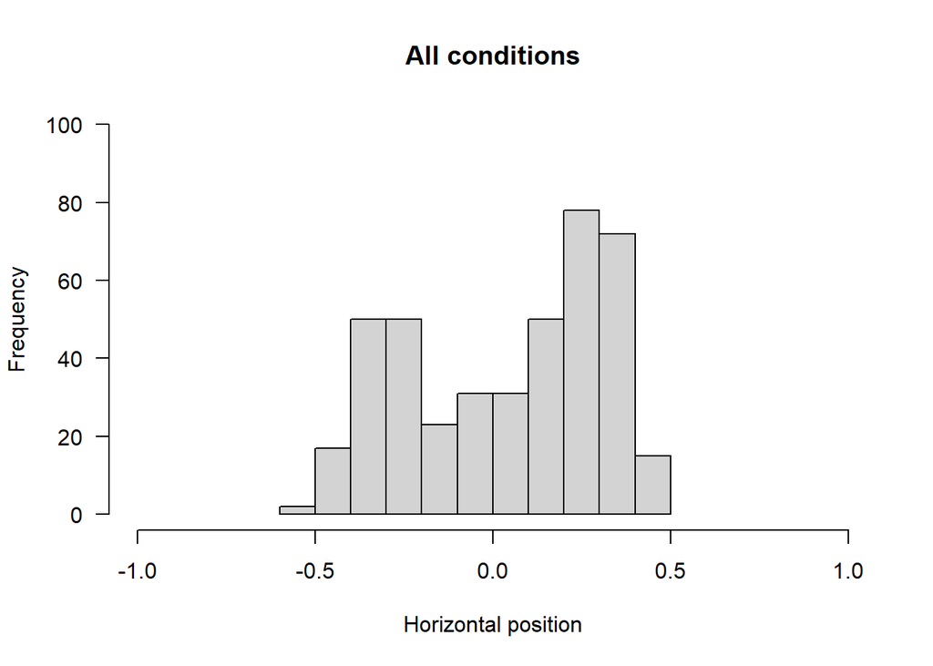

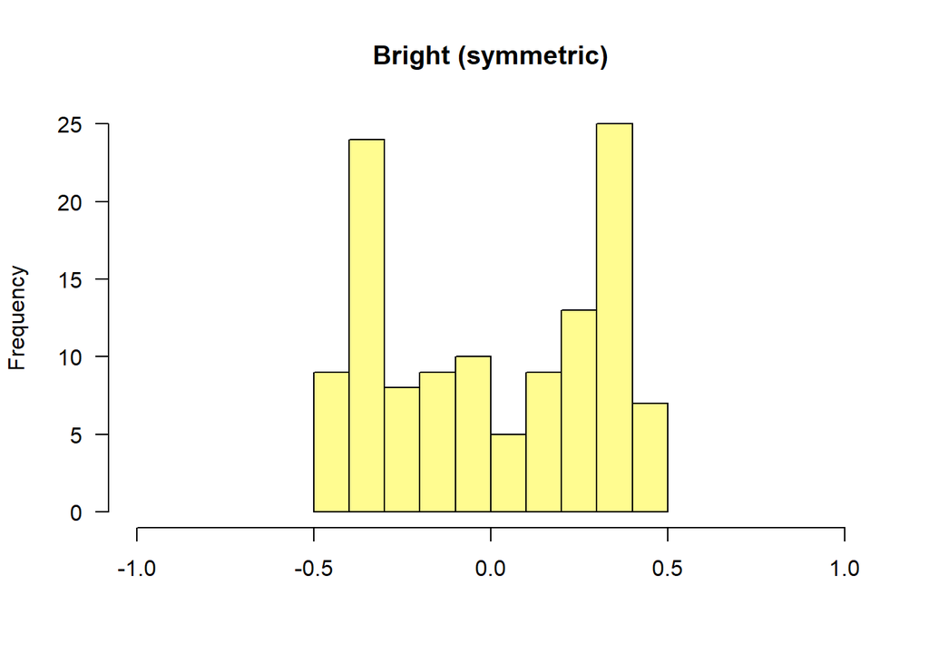

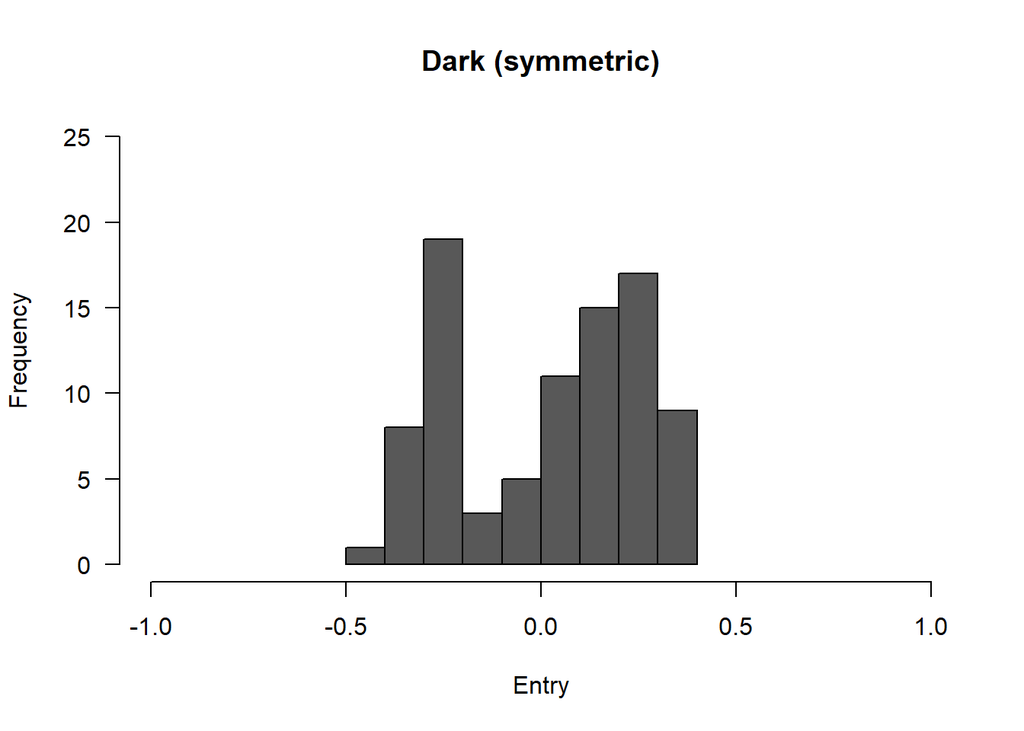

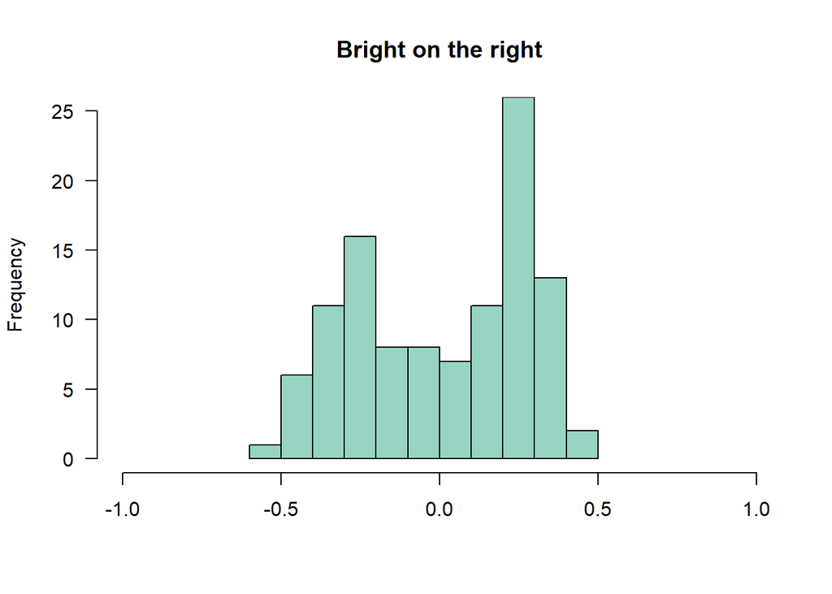

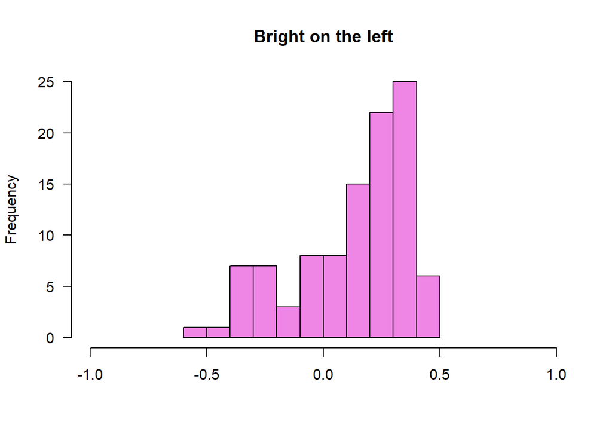

## Modality

The distributions shown above do not appear to all be be unimodal, thus, we conducted a Hartigan’s dip test to test for unimodality of the data for each brightness condition.

```r
library(diptest) # package used to compute Hartigan's dip test
library(multimode) # package used to compute the mode(s) of the entry point, which is a continuous variable

dip.test(bright_df$Entry)
```

```
##
##  Hartigans' dip test for unimodality / multimodality
##
## data:  bright_df$Entry
## D = 0.07191, p-value = 6.358e-05
## alternative hypothesis: non-unimodal, i.e., at least bimodal
```

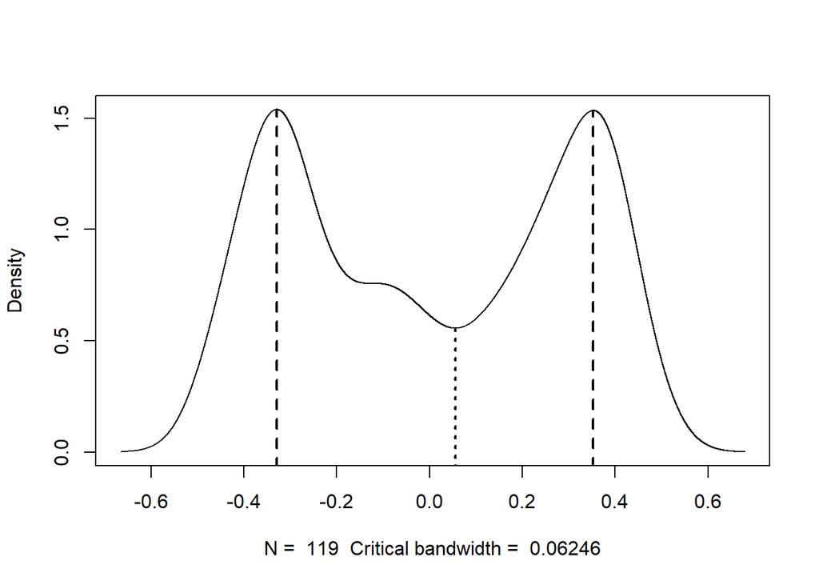

```r
bright_modes <- locmodes(bright_df$Entry, mod0 = 2, display=TRUE, addplot=FALSE, addLegend=FALSE)
```

```r
bright_modes
```

```
##
## Estimated location
## Modes: -0.3291701  0.3526277
## Antimode: 0.0554464
##
## Estimated value of the density
## Modes: 1.539844  1.535206
## Antimode: 0.5567151
##
## Critical bandwidth: 0.06246185
```

```r
dip.test(dark_df$Entry)
```

```
##
##  Hartigans' dip test for unimodality / multimodality
##
## data:  dark_df$Entry
## D = 0.066179, p-value = 0.004635
## alternative hypothesis: non-unimodal, i.e., at least bimodal
```

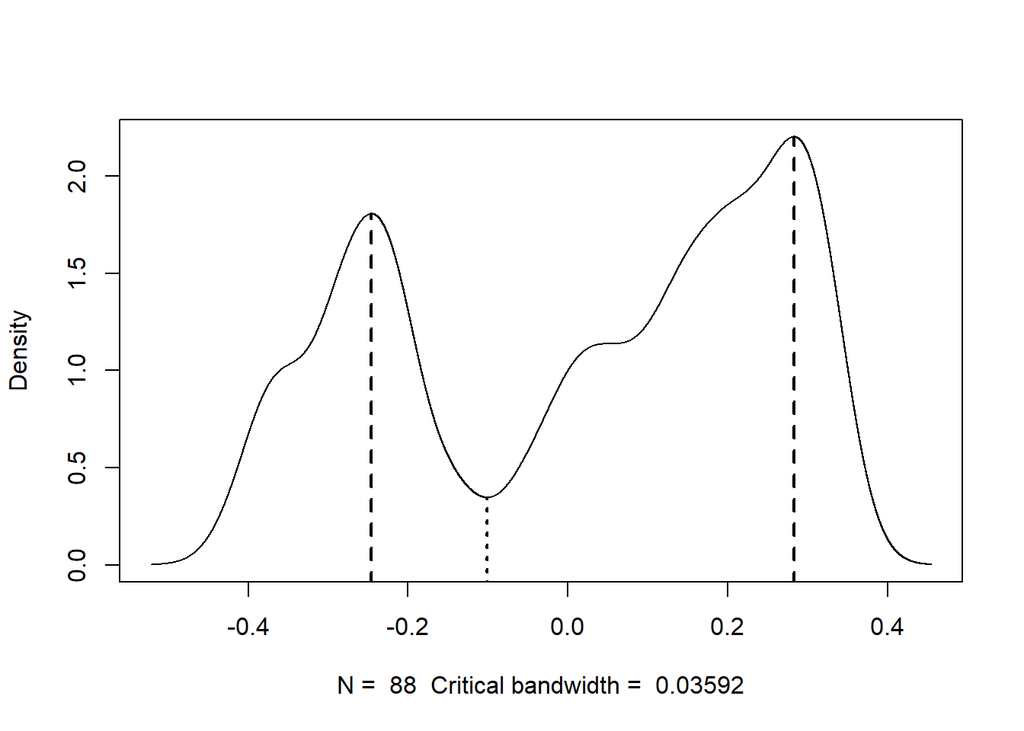

```r
dark_modes <- locmodes(dark_df$Entry, mod0 = 2, display=TRUE, addplot=FALSE, addLegend=FALSE)
```

```r
dark_modes
```

```
##
## Estimated location
## Modes: -0.2459138  0.2824842
## Antimode: -0.1013287
##
## Estimated value of the density
## Modes: 1.807624  2.203769
## Antimode: 0.3465787
##
## Critical bandwidth: 0.03591919
```

```r
dip.test(left_bright_df$Entry)
```

```
##
##  Hartigans' dip test for unimodality / multimodality
##
## data:  left_bright_df$Entry
## D = 0.025286, p-value = 0.9502
## alternative hypothesis: non-unimodal, i.e., at least bimodal
```

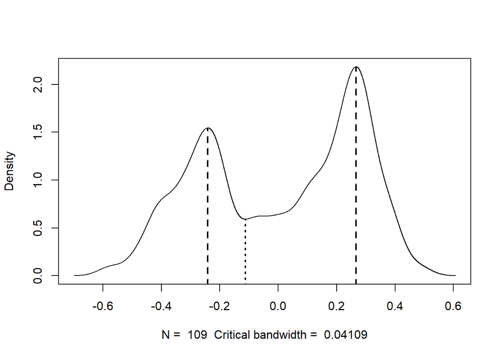

```r
right_bright_modes <- locmodes(right_bright_df$Entry, mod0 = 2, display=TRUE, addplot=FALSE, addLegend=FALSE)
```

```r
right_bright_modes
```

```
##
## Estimated location
## Modes: -0.2408147  0.2666288
## Antimode: -0.1121193
##
## Estimated value of the density
## Modes: 1.545887  2.184316
## Antimode: 0.5914341
##
## Critical bandwidth: 0.04109192
```

```r
dip.test(right_bright_df$Entry)
```

```
##
##  Hartigans' dip test for unimodality / multimodality
##
## data:  right_bright_df$Entry
## D = 0.057334, p-value = 0.008826
## alternative hypothesis: non-unimodal, i.e., at least bimodal
```

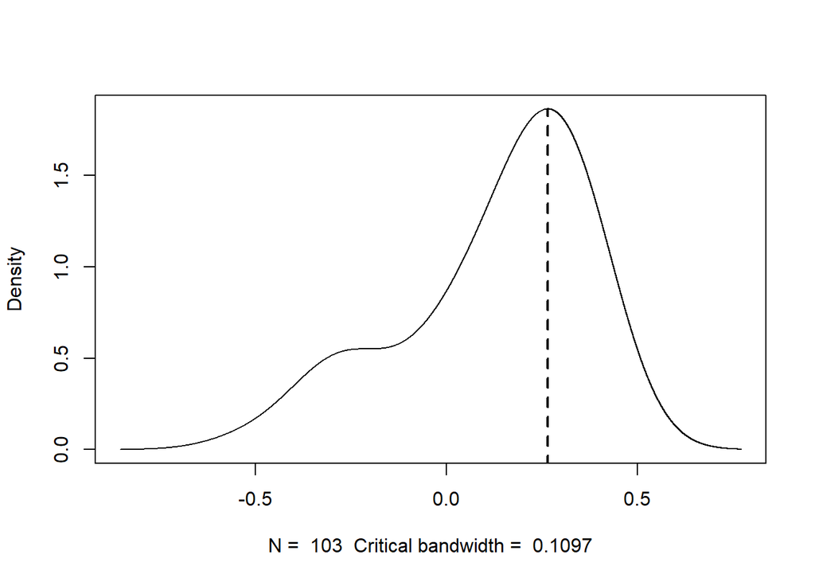

```r
left_bright_modes <- locmodes(left_bright_df$Entry, mod0 = 1, display=TRUE, addplot=FALSE, addLegend=FALSE)
```

```r
left_bright_modes
```

```
##
## Estimated location
## Mode: 0.2655605
##
## Estimated value of the density
## Mode: 1.864092
##
## Critical bandwidth: 0.1096725
```

## Effects of brightness condition on Origin side

```r
# We exclude the ambiguous data points for Origin from the analysis
Origin_table <- with(subset(df, Origin!='?'), table(Treatment, Origin))
Origin_table
```

```
##                Origin
## Treatment       Left Right
##   Bright-Dark     18    77
##   Dark-Bright     42    60
##   Bright-Bright   56    60
##   Dark-Dark       35    51
```

We use this table to compute the proportions of Left and Right origin for each brightness Treatment. We then find the confidence intervals for these proportions using the method of Agresti and Coull, computed in Excel. We import the lower and upper bounds of these intervals from the Excel file named ‘barplots_CI_tables.xlsx’:

```r
origin_freq_df <- read_excel("barplots_CI_tables.xlsx", sheet = 2)
origin_freq_df$Treatment <- factor(origin_freq_df$Treatment,
                                   levels=c("Left", "Right", "Bright", "Dark"))
```

We plot the proportions of flights originating from the left vs right (relative to the total of recorded flights), with the confidence intervals obtained above.

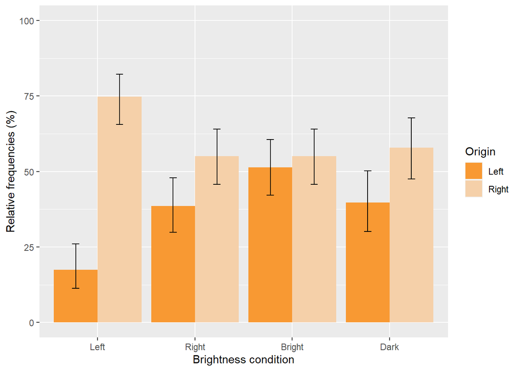

## Effects of brightness condition on Arrival side

```r
# We exclude the ambiguous data points for Arrival from the analysis
Arrival_table <- with(subset(df, Arrival!='?'), table(Treatment, Arrival))
Arrival_table
```

```
##                Arrival
## Treatment       Left Right
##   Bright-Dark     66    20
##   Dark-Bright      4   102
##   Bright-Bright   40    65
##   Dark-Dark        1    70
```

Similarly, we use the above table to compute the proportions of Left and Right arrivals for each brightness Treatment. Once again, we then find the confidence intervals for these proportions using the method of Agresti and Coull, computed in Excel. We import the lower and upper bounds of these intervals from the same Excel file:

```r
arrival_freq_df <- read_excel("barplots_CI_tables.xlsx", sheet = 1)
arrival_freq_df$Treatment <- factor(arrival_freq_df$Treatment,
                                   levels=c("Left", "Right", "Bright", "Dark"))
```

We plot the proportions of flights arriving on the left vs right (relative to the total of recorded flights), with the confidence intervals obtained above.

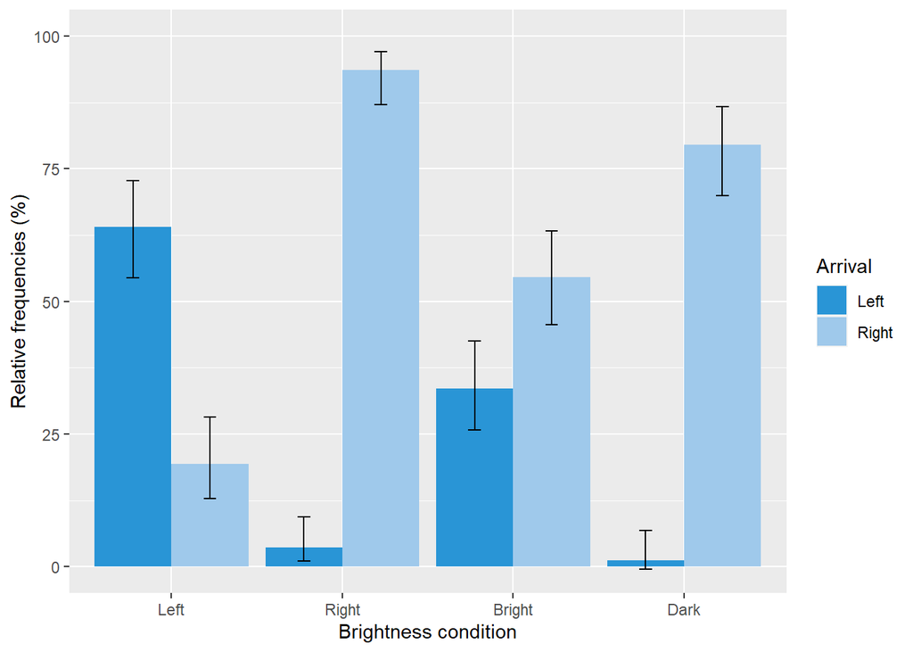

## Effect of brightness condition on entry after grouping data by origin

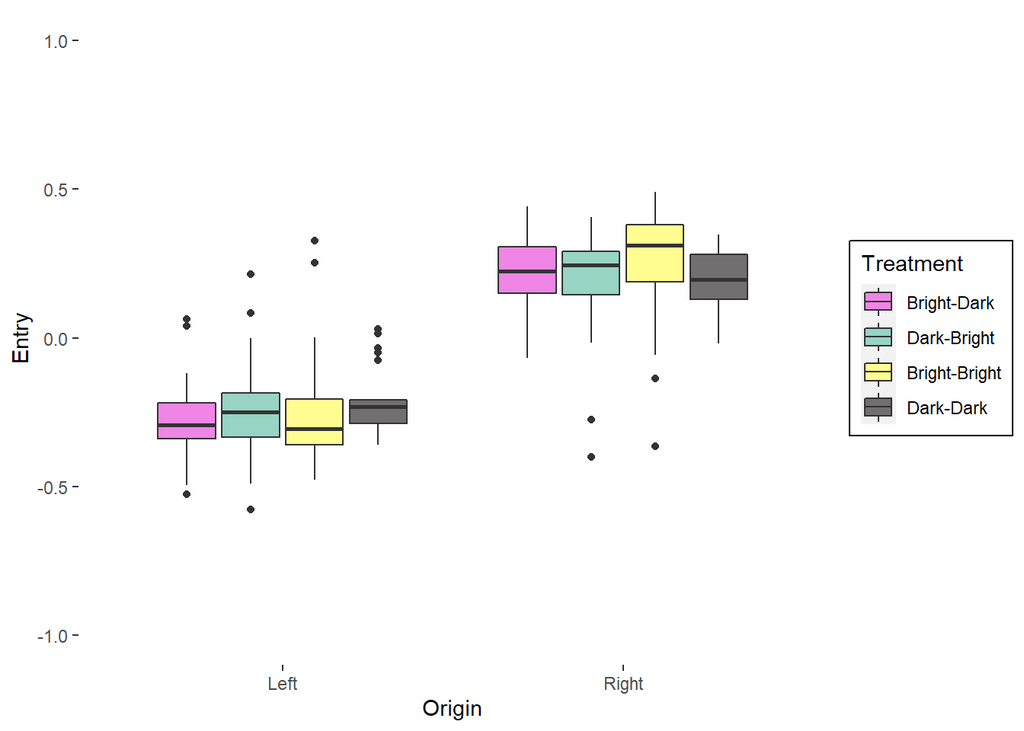

## Effect of arrival side on entry after grouping data by origin

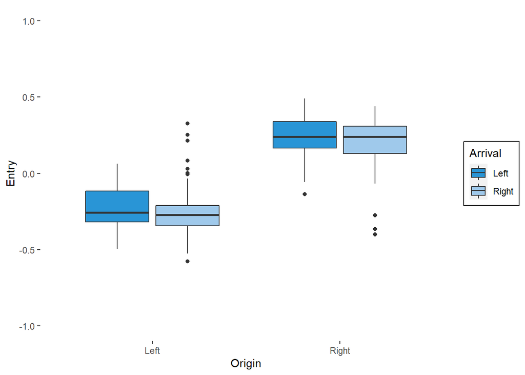

# Statistical analysis

## Check for normality of data distribution

First, we look at the distribution of residuals for the simplest linear model: Entry ~ Origin

```r
origin_lm <- lm(Entry ~ Origin, data = df)
plot_residuals(origin_lm)
```

[output not shown]

Then, we look at the distribution of residuals for the following two way ANOVA (in Statistical Analysis section): Entry ~ Origin*Treatment

```r
ori_treatment_lm <- lm(Entry ~ Origin*Treatment, data = df)
plot_residuals(ori_treatment_lm)
```

[output not shown]

```r
arr_treatment_lm <- lm(Entry ~ Origin*Arrival, data = df)
plot_residuals(plot_residuals(ori_treatment_lm))
```

[output not shown]

## Categorical data analysis

### Chi-squared test

Testing for an effect of the brightness condition on the preferred side of Origin

```r
# We exclude the ambiguous data points for Arrival from the analysis
Origin_table <- with(subset(df, Origin!='?'), table(Treatment, Origin))
Origin_table
```

```
##                Origin
## Treatment       Left Right
##   Bright-Dark     18    77
##   Dark-Bright     42    60
##   Bright-Bright   56    60
##   Dark-Dark       35    51
```

```r
chisq.test(Origin_table)
```

```
##
##  Pearson's Chi-squared test
##
## data:  Origin_table
## X-squared = 20.567, df = 3, p-value = 0.0001295
```

### Chi-squared test

Testing for an effect of the brightness condition on the preferred side of Arrival

```r
# We exclude the ambiguous data points for Arrival from the analysis
Arrival_table <- with(subset(df, Arrival!='?'), table(Treatment, Arrival))
Arrival_table
```

```
##                Arrival
## Treatment       Left Right
##   Bright-Dark     66    20
##   Dark-Bright      4   102
##   Bright-Bright   40    65
##   Dark-Dark        1    70
```

```r
chisq.test(Arrival_table)
```

```
##
##  Pearson's Chi-squared test
##
## data:  Arrival_table
## X-squared = 154.63, df = 3, p-value < 2.2e-16
```

## Continuous data analysis

### Two-sample t-test

Checking for any significant effect of Origin on the point of Entry

```r
t.test(Entry ~ Origin, data = subset(df,Origin!='?'), var.equal = TRUE, paired = FALSE, alternative="two.sided")
```

```
##
##  Two Sample t-test
##
## data:  Entry by Origin
## t = -30.806, df = 397, p-value < 2.2e-16
## alternative hypothesis: true difference in means is not equal to 0
## 95 percent confidence interval:
##  -0.5009154 -0.4408169
## sample estimates:
##  mean in group Left mean in group Right
##          -0.2452240           0.2256421
```

```
## [1] "Birds originating from the right tended to enter to the right of centre (f = 0.225642 ± 0.146782; mean ± s.d; n = 248)"
```

```
## [1] "Birds originating from the left tended to enter to the left of centre (f = -0.245224 ± 0.150185; mean ± s.d; n = 151)"
```

### Two-way ANOVAs

1. Checking for any significant interaction between the effect of Origin side and the effect of the brightness condition:

```r
# 2-way ANOVA with Treatment (brightness) and Origin as factors + their interaction
anova_brightness <- aov(Entry ~ Origin*Treatment, data = subset(df,Origin!='?' & Arrival!='?'& (Treatment=='Dark-Bright' | Treatment=='Bright-Dark')))
summary(anova_brightness)
```

```
##                   Df Sum Sq Mean Sq F value Pr(>F)
## Origin             1  8.484   8.484 420.310 <2e-16 ***
## Treatment          1  0.000   0.000   0.001  0.979
## Origin:Treatment   1  0.015   0.015   0.722  0.397
## Residuals        173  3.492   0.020
## ---
## Signif. codes:  0 '***' 0.001 '**' 0.01 '*' 0.05 '.' 0.1 ' ' 1
```

2. Checking for any significant interaction between the effect of Origin side and the effect of Arrival side:

```r
# 2-way ANOVA with Arrival and Origin as factors + their interaction
anova_arrival <- aov(Entry ~ Origin*Arrival, data = subset(df, (Origin!='?' & Arrival!='?')))
summary(anova_arrival)
```

```
##                 Df Sum Sq Mean Sq F value Pr(>F)
## Origin           1 18.373  18.373 896.745 <2e-16 ***
## Arrival          1  0.102   0.102   4.975 0.0264 *
## Origin:Arrival   1  0.001   0.001   0.044 0.8348
## Residuals      345  7.068   0.020
## ---
## Signif. codes:  0 '***' 0.001 '**' 0.01 '*' 0.05 '.' 0.1 ' ' 1
```